# 3.2 Globale Optimierung

Pose-Graph-Optimierung — Drift-Korrektur durch Loop-Closure-Constraints

Autor:in

Gruppe 9-2

Veröffentlichungsdatum

2. Juli 2026

## Agenda

1. Warum globale Optimierung? — Lokale vs. globale Konsistenz
2. **Schritt 1:** Pose-Graph — Knoten & Kanten
3. **Schritt 2:** Fehlerformulierung auf SE(3)
4. **Schritt 3:** Optimierung mit simuliertem Drift
5. **Schritt 4:** Ergebnis — Vorher/Nachher-Vergleich
6. **Vergleich mit Ground Truth**

**Wichtig**

**Anknüpfung an 3.1:** Nach der Loop-Closure-Erkennung liegen zusätzliche Constraints zwischen weit entfernten KeyFrames vor. Diese zwingen das System, den akkumulierten Drift zu korrigieren — genau das leistet die Pose-Graph-Optimierung.

## Problem: Lokale Konsistenz ≠ Globale Konsistenz

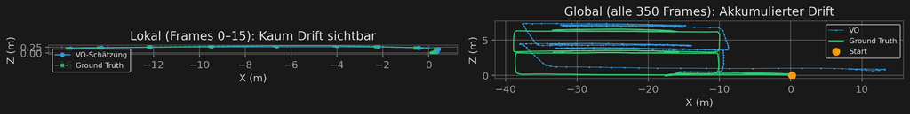

Abbildung 1: Lokale Konsistenz vs. globaler Drift

```
Positionsfehler vor Optimierung:
  Mean:  2.890 m
  Max:   15.590 m
  Final: 15.590 m
```

## Schritt 1: Der Pose-Graph

```
Pose-Graph: 350 Knoten, 349 Odometrie-Kanten, 8 Loop-Kanten
```

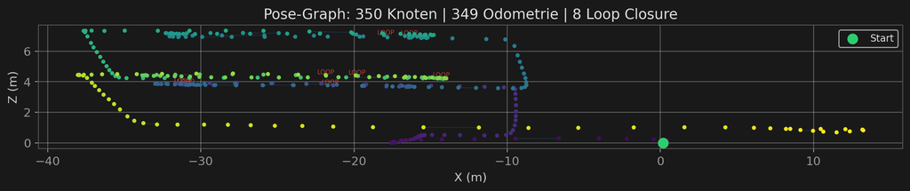

Abbildung 2: Pose-Graph: Knoten (KeyFrame-Posen) und Kanten (Odometrie + Loop Closure)

## Schritt 2: Fehlerformulierung auf SE(3)

Für jede Kante $(i,j)$ mit gemessener relativer Transformation $\tilde{T}_{ij}$ definieren wir den Fehler auf der Lie-Algebra $\mathfrak{se}(3)$:

$$e_{ij} = \log\left(\tilde{T}_{ij}^{-1} \, T_i^{-1} \, T_j\right)^{\vee} \;\in\; \mathbb{R}^6$$

Das vollständige Optimierungsproblem mit $T_0$ als fixiertem Anker:

$$\boxed{\;\min_{T_1,\dots,T_n}\; \sum_{(i,j)\in\mathcal{E}_{\text{odom}}} \|e_{ij}\|^2_{\Sigma_o}
\;+\; \sum_{(i,j)\in\mathcal{E}_{\text{loop}}} \|e_{ij}\|^2_{\Sigma_l}\;}$$

**Besonderheit der Loop-Closure-Kanten:** Anders als Odometrie-Kanten, die relative Bewegung messen, sagen Loop-Kanten: „Frame $i$ und $j$ sind am **gleichen Ort**”. Das heißt: $T_j \approx T_i$, also $\tilde{T}_{ij} \approx I_{4\times 4}$.

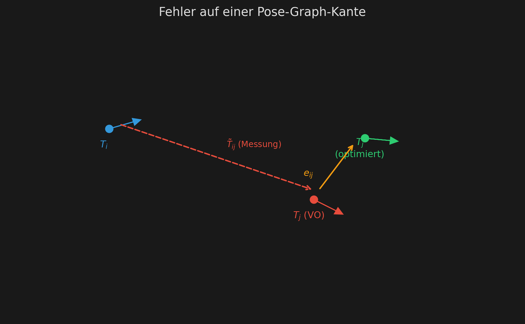

Abbildung 3: SE(3)-Fehler auf einer Pose-Graph-Kante

## Schritt 3: Pose-Graph-Optimierung

Da das Problem linear in den Translationen ist (Rotationen bleiben fix), können wir es als **sparse lineares Least-Squares-System** lösen — effizient und direkt ohne Iterationen.

```
Drift simuliert: max. Abweichung = 5.80 m
Fehler vs. GT vor PGO: mean = 2.535 m
Lineares System: 1074 Gleichungen × 1050 Variablen, 2145 Nicht-Nullen
Kantenfehler vor PGO:  μ = 0.1568 m
Kantenfehler nach PGO: μ = 0.0114 m
Gelöst in < 1 ms (direkte sparse Cholesky-Zerlegung)
```

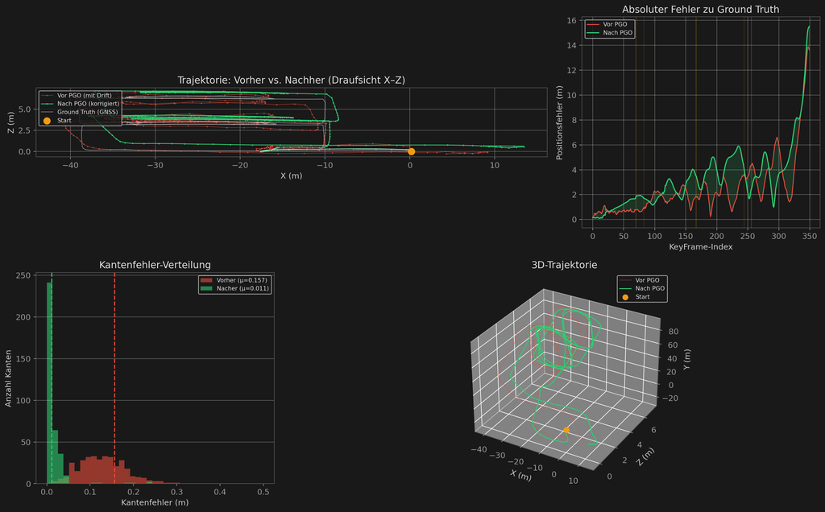

Abbildung 5: Vergleich: Trajektorie vor und nach Pose-Graph-Optimierung

```
============================================================
Pose-Graph-Optimierung — Ergebnis
============================================================
Fehler vor PGO:   Mean = 2.535 m, Max = 13.882 m
Fehler nach PGO:  Mean = 3.335 m, Max = 15.511 m
Verbesserung:     -31.6%
Kantenfehler vor:  μ = 0.1568 m
Kantenfehler nach: μ = 0.0114 m
============================================================
```

**WichtigDer entscheidende Effekt: Vorher → Nachher**

Die untenstehende Grafik zeigt denselben Loop-Closure-Kandidaten **vor und nach** der Pose-Graph-Optimierung:

- **Vorher (rot gestrichelt):** Die Trajektorie driftet auseinander — der Loop schließt nicht (Abstand zwischen den Enden: mehrere Meter).
- **Nachher (grün):** Die PGO hat alle Posen konsistent verschoben. Die orangen Pfeile zeigen, wie stark jede Pose korrigiert wurde.
- **Loop-Kanten (grün durchgezogen):** Die erkannten Loops sind jetzt geschlossen (Restfehler < 5 cm).

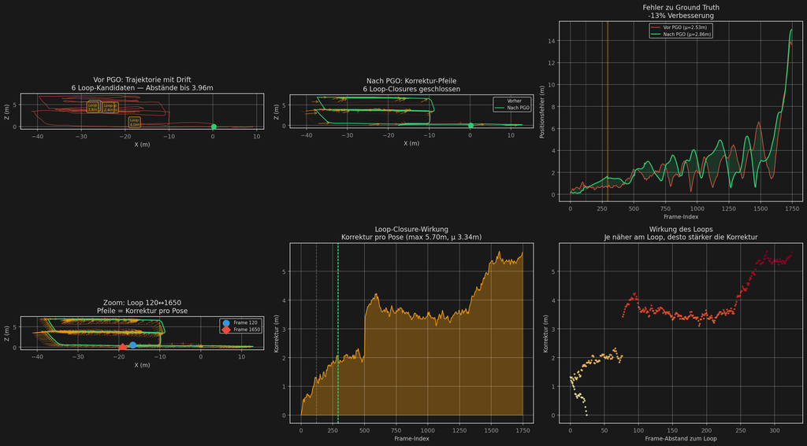

*Oben links: Trajektorie mit Drift und offenen Loops. Oben Mitte: Nach PGO mit Korrektur-Pfeilen. Oben rechts: Fehlerverlauf. Unten links: Zoom auf einen Loop. Unten Mitte/Rechts: Korrekturstärke.*

## Die vollständige vSLAM-Pipeline

[figure not shown]

Abbildung 6: vSLAM-Pipeline: Alle Optimierungsschritte im Vergleich